# Supervised Learning - Foundations Project: ReCell

Derek Ruthardt

## Problem Statement

### Business Context

Buying and selling used phones and tablets used to be something that happened on a handful of online marketplace sites. But the used and refurbished device market has grown considerably over the past decade, and a new IDC (International Data Corporation) forecast predicts that the used phone market would be worth \$52.7bn by 2023 with a compound annual growth rate (CAGR) of 13.6% from 2018 to 2023. This growth can be attributed to an uptick in demand for used phones and tablets that offer considerable savings compared with new models.

Refurbished and used devices continue to provide cost-effective alternatives to both consumers and businesses that are looking to save money when purchasing one. There are plenty of other benefits associated with the used device market. Used and refurbished devices can be sold with warranties and can also be insured with proof of purchase. Third-party vendors/platforms, such as Verizon, Amazon, etc., provide attractive offers to customers for refurbished devices. Maximizing the longevity of devices through second-hand trade also reduces their environmental impact and helps in recycling and reducing waste. The impact of the COVID-19 outbreak may further boost this segment as consumers cut back on discretionary spending and buy phones and tablets only for immediate needs.

### Objective

The rising potential of this comparatively under-the-radar market fuels the need for an ML-based solution to develop a dynamic pricing strategy for used and refurbished devices. ReCell, a startup aiming to tap the potential in this market, has hired you as a data scientist. They want you to analyze the data provided and build a linear regression model to predict the price of a used phone/tablet and identify factors that significantly influence it.

### Data Description

The data contains the different attributes of used/refurbished phones and tablets. The data was collected in the year 2021. The detailed data dictionary is given below.

- brand_name: Name of manufacturing brand
- os: OS on which the device runs
- screen_size: Size of the screen in cm
- 4g: Whether 4G is available or not
- 5g: Whether 5G is available or not
- main_camera_mp: Resolution of the rear camera in megapixels
- selfie_camera_mp: Resolution of the front camera in megapixels
- int_memory: Amount of internal memory (ROM) in GB
- ram: Amount of RAM in GB
- battery: Energy capacity of the device battery in mAh
- weight: Weight of the device in grams
- release_year: Year when the device model was released
- days_used: Number of days the used/refurbished device has been used
- normalized_new_price: Normalized price of a new device of the same model in euros
- normalized_used_price: Normalized price of the used/refurbished device in euros

## Importing necessary libraries

```python
# Installing the libraries with the specified version.
import pandas as pd
import numpy as np

# For visualizing data
import matplotlib.pyplot as plt
import seaborn as sns

# For randomized data splitting
from sklearn.model_selection import train_test_split

# To build linear regression_model
import statsmodels.api as sm

# To check model performance
from sklearn.metrics import mean_absolute_error, mean_squared_error

# To build linear regression_model using statsmodels
import statsmodels.api as sm

# To compute VIF
from statsmodels.stats.outliers_influence import variance_inflation_factor
```

**Note**: *After running the above cell, kindly restart the notebook kernel and run all cells sequentially from the start again.*

## Loading the dataset

```python
from google.colab import drive
drive.mount('/content/drive')
```

```python
data = pd.read_csv('/content/drive/MyDrive/Supervised_Learning/used_device_data.csv')
```

```python
# Create a copy of the data
df = data.copy()
```

## Data Overview

```python
# check the first and last 5 rows of the data
display(df.head())
display(df.tail())
```

|  | brand_name | os | screen_size | 4g | 5g | main_camera_mp | selfie_camera_mp | int_memory | ram | battery | weight | release_year | days_used | normalized_used_price | normalized_new_price |
| --- | --- | --- | --- | --- | --- | --- | --- | --- | --- | --- | --- | --- | --- | --- | --- |
| 0 | Honor | Android | 14.50 | yes | no | 13.0 | 5.0 | 64.0 | 3.0 | 3020.0 | 146.0 | 2020 | 127 | 4.307572 | 4.715100 |
| 1 | Honor | Android | 17.30 | yes | yes | 13.0 | 16.0 | 128.0 | 8.0 | 4300.0 | 213.0 | 2020 | 325 | 5.162097 | 5.519018 |
| 2 | Honor | Android | 16.69 | yes | yes | 13.0 | 8.0 | 128.0 | 8.0 | 4200.0 | 213.0 | 2020 | 162 | 5.111084 | 5.884631 |
| 3 | Honor | Android | 25.50 | yes | yes | 13.0 | 8.0 | 64.0 | 6.0 | 7250.0 | 480.0 | 2020 | 345 | 5.135387 | 5.630961 |
| 4 | Honor | Android | 15.32 | yes | no | 13.0 | 8.0 | 64.0 | 3.0 | 5000.0 | 185.0 | 2020 | 293 | 4.389995 | 4.947837 |

|  | brand_name | os | screen_size | 4g | 5g | main_camera_mp | selfie_camera_mp | int_memory | ram | battery | weight | release_year | days_used | normalized_used_price | normalized_new_price |
| --- | --- | --- | --- | --- | --- | --- | --- | --- | --- | --- | --- | --- | --- | --- | --- |
| 3449 | Asus | Android | 15.34 | yes | no | NaN | 8.0 | 64.0 | 6.0 | 5000.0 | 190.0 | 2019 | 232 | 4.492337 | 6.483872 |
| 3450 | Asus | Android | 15.24 | yes | no | 13.0 | 8.0 | 128.0 | 8.0 | 4000.0 | 200.0 | 2018 | 541 | 5.037732 | 6.251538 |
| 3451 | Alcatel | Android | 15.80 | yes | no | 13.0 | 5.0 | 32.0 | 3.0 | 4000.0 | 165.0 | 2020 | 201 | 4.357350 | 4.528829 |
| 3452 | Alcatel | Android | 15.80 | yes | no | 13.0 | 5.0 | 32.0 | 2.0 | 4000.0 | 160.0 | 2020 | 149 | 4.349762 | 4.624188 |
| 3453 | Alcatel | Android | 12.83 | yes | no | 13.0 | 5.0 | 16.0 | 2.0 | 4000.0 | 168.0 | 2020 | 176 | 4.132122 | 4.279994 |

```python
# check the shape of the data
df.shape
```

```
(3454, 15)
```

Our head and tail of the df correspond to the shape of the df

```python
# check column types and number of values
df.info()
```

```
<class 'pandas.core.frame.DataFrame'>
RangeIndex: 3454 entries, 0 to 3453
Data columns (total 15 columns):
 #   Column                 Non-Null Count  Dtype
---  ------                 --------------  -----
 0   brand_name             3454 non-null   object
 1   os                     3454 non-null   object
 2   screen_size            3454 non-null   float64
 3   4g                     3454 non-null   object
 4   5g                     3454 non-null   object
 5   main_camera_mp         3275 non-null   float64
 6   selfie_camera_mp       3452 non-null   float64
 7   int_memory             3450 non-null   float64
 8   ram                    3450 non-null   float64
 9   battery                3448 non-null   float64
 10  weight                 3447 non-null   float64
 11  release_year           3454 non-null   int64
 12  days_used              3454 non-null   int64
 13  normalized_used_price  3454 non-null   float64
 14  normalized_new_price   3454 non-null   float64
dtypes: float64(9), int64(2), object(4)
memory usage: 404.9+ KB
```

```python
# check for missing data
df.isnull().sum()
```

|  | 0 |
| --- | --- |
| brand_name | 0 |
| os | 0 |
| screen_size | 0 |
| 4g | 0 |
| 5g | 0 |
| main_camera_mp | 179 |
| selfie_camera_mp | 2 |
| int_memory | 4 |
| ram | 4 |
| battery | 6 |
| weight | 7 |
| release_year | 0 |
| days_used | 0 |
| normalized_used_price | 0 |
| normalized_new_price | 0 |

**dtype:** int64

Six columns are missing data. These are numerical variables, and will be treated later.

```python
# check the statistical summary of the data
df.describe().T
```

|  | count | mean | std | min | 25% | 50% | 75% | max |
| --- | --- | --- | --- | --- | --- | --- | --- | --- |
| screen_size | 3454.0 | 13.713115 | 3.805280 | 5.080000 | 12.700000 | 12.830000 | 15.340000 | 30.710000 |
| main_camera_mp | 3275.0 | 9.460208 | 4.815461 | 0.080000 | 5.000000 | 8.000000 | 13.000000 | 48.000000 |
| selfie_camera_mp | 3452.0 | 6.554229 | 6.970372 | 0.000000 | 2.000000 | 5.000000 | 8.000000 | 32.000000 |
| int_memory | 3450.0 | 54.573099 | 84.972371 | 0.010000 | 16.000000 | 32.000000 | 64.000000 | 1024.000000 |
| ram | 3450.0 | 4.036122 | 1.365105 | 0.020000 | 4.000000 | 4.000000 | 4.000000 | 12.000000 |
| battery | 3448.0 | 3133.402697 | 1299.682844 | 500.000000 | 2100.000000 | 3000.000000 | 4000.000000 | 9720.000000 |
| weight | 3447.0 | 182.751871 | 88.413228 | 69.000000 | 142.000000 | 160.000000 | 185.000000 | 855.000000 |
| release_year | 3454.0 | 2015.965258 | 2.298455 | 2013.000000 | 2014.000000 | 2015.500000 | 2018.000000 | 2020.000000 |
| days_used | 3454.0 | 674.869716 | 248.580166 | 91.000000 | 533.500000 | 690.500000 | 868.750000 | 1094.000000 |
| normalized_used_price | 3454.0 | 4.364712 | 0.588914 | 1.536867 | 4.033931 | 4.405133 | 4.755700 | 6.619433 |
| normalized_new_price | 3454.0 | 5.233107 | 0.683637 | 2.901422 | 4.790342 | 5.245892 | 5.673718 | 7.847841 |

```python
# check the dataset for duplicates
df.duplicated().sum()
```

```
0
```

There are no duplicates in the df

Most of the columns in the data are numeric in nature ('int64' or 'float64' type).

The brand_name, os, 4g and 5g columns are string columns ('object' type).

We will treat the missing data and perform other treatment after doing some initial EDA

## Exploratory Data Analysis (EDA)

- EDA is an important part of any project involving data.
- It is important to investigate and understand the data better before building a model with it.
- A few questions have been mentioned below which will help you approach the analysis in the right manner and generate insights from the data.
- A thorough analysis of the data, in addition to the questions mentioned below, should be done.

**Questions**:

1. What does the distribution of normalized used device prices look like?
2. What percentage of the used device market is dominated by Android devices?
3. The amount of RAM is important for the smooth functioning of a device. How does the amount of RAM vary with the brand?
4. A large battery often increases a device's weight, making it feel uncomfortable in the hands. How does the weight vary for phones and tablets offering large batteries (more than 4500 mAh)?
5. Bigger screens are desirable for entertainment purposes as they offer a better viewing experience. How many phones and tablets are available across different brands with a screen size larger than 6 inches?
6. A lot of devices nowadays offer great selfie cameras, allowing us to capture our favorite moments with loved ones. What is the distribution of devices offering greater than 8MP selfie cameras across brands?
7. Which attributes are highly correlated with the normalized price of a used device?

We will address the 7 questions above first and then perform more thorough data analysis.

Q1: What does the distribution of normalized used device prices look like?

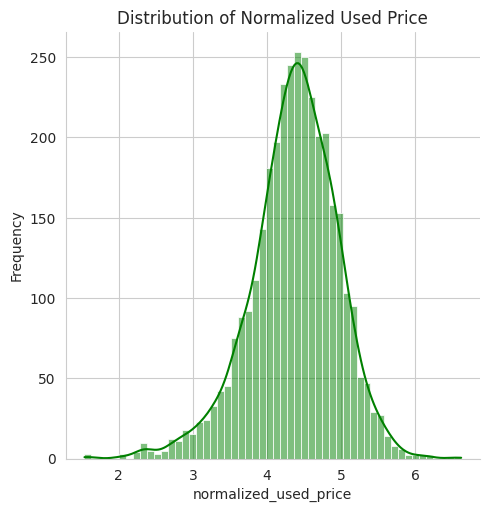

```python
# plot distribution of normalized_used price using seaborn
sns.displot(df['normalized_used_price'], kde=True, color='g')
plt.xlabel('normalized_used_price')
plt.ylabel('Frequency')
plt.title('Distribution of Normalized Used Price')
plt.show()
```

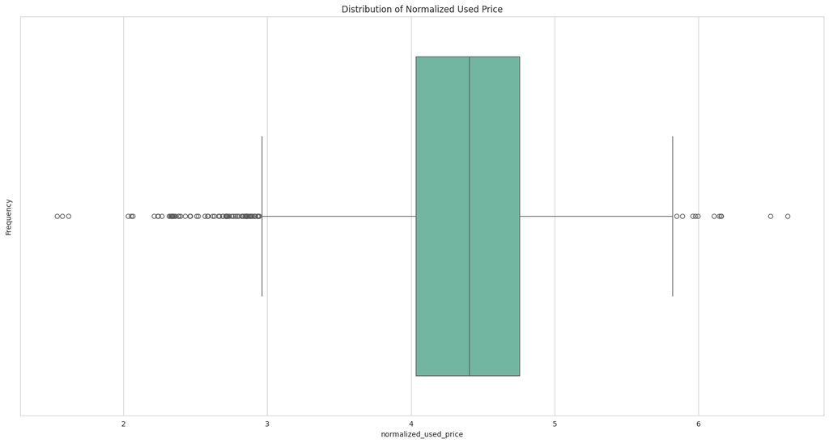

```python
# boxplot for nomalized used price

sns.boxplot(x=df['normalized_used_price'])
plt.xlabel('normalized_used_price')
plt.ylabel('Frequency')
plt.title('Distribution of Normalized Used Price')
plt.show()
```

A1: The distribution is normally distributed with a slight skew to the left.

There are a few outliers to the left and right. It is reasonable to expect a few outliers for used phone pricing given the amount of variables that affect price. For now, we will keep these in the dataset unless we see a reason to remove them.

Q2: What percentage of the used device market is dominated by Android devices?

```python
# Find the percentage of android os in the df
df['os'].value_counts(normalize=True) * 100
```

| os | proportion |
| --- | --- |
| Android | 93.051534 |
| Others | 3.966416 |
| Windows | 1.939780 |
| iOS | 1.042270 |

**dtype:** float64

A2: Android represents 93.05 % of the used device market.

Q3: The amount of RAM is important for the smooth functioning of a device. How does the amount of RAM vary with the brand?

```python
# Create a new df with ram by brand_name
ram_by_brand = df.groupby('brand_name')['ram'].mean().reset_index()
# Add a new column for variance of ram in ram_by_brand
ram_by_brand['ram_var'] = df.groupby('brand_name')['ram'].var().reset_index()['ram']
# Sort ram_by_brand by highest variance
ram_by_brand = ram_by_brand.sort_values(by='ram_var', ascending=False)
```

```python
# Show ram_by_brand
ram_by_brand
```

|  | brand_name | ram | ram_var |
| --- | --- | --- | --- |
| 22 | OnePlus | 6.363636 | 6.718615 |
| 23 | Oppo | 4.961240 | 4.506298 |
| 21 | Nokia | 2.420294 | 3.569549 |
| 5 | Celkon | 1.613636 | 3.355824 |
| 30 | Vivo | 4.756410 | 2.683687 |
| 10 | Honor | 4.603448 | 2.641379 |
| 11 | Huawei | 4.655378 | 2.545261 |
| 32 | Xiaomi | 4.583333 | 2.275445 |
| 13 | Karbonn | 3.353448 | 2.078202 |
| 15 | Lava | 3.277778 | 1.999206 |
| 27 | Samsung | 4.199413 | 1.896514 |
| 20 | Motorola | 3.943396 | 1.768194 |
| 26 | Realme | 4.195122 | 1.760976 |
| 1 | Alcatel | 3.407025 | 1.597013 |
| 17 | Meizu | 4.451613 | 1.497620 |
| 14 | LG | 3.936567 | 1.158769 |
| 18 | Micromax | 3.679487 | 1.108670 |
| 24 | Others | 3.777888 | 1.031905 |
| 29 | Spice | 3.750000 | 0.905172 |
| 8 | Google | 4.533333 | 0.838095 |
| 33 | ZTE | 4.023214 | 0.827245 |
| 12 | Infinix | 2.600000 | 0.711111 |
| 4 | BlackBerry | 3.829545 | 0.639205 |
| 16 | Lenovo | 3.885965 | 0.599420 |
| 2 | Apple | 4.000000 | 0.368421 |
| 3 | Asus | 4.049180 | 0.361198 |
| 7 | Gionee | 3.933036 | 0.251116 |
| 0 | Acer | 3.901961 | 0.250196 |
| 28 | Sony | 4.069767 | 0.230369 |
| 9 | HTC | 4.000000 | 0.110092 |
| 6 | Coolpad | 3.954545 | 0.045455 |
| 19 | Microsoft | 4.000000 | 0.000000 |
| 25 | Panasonic | 4.000000 | 0.000000 |
| 31 | XOLO | 4.000000 | 0.000000 |

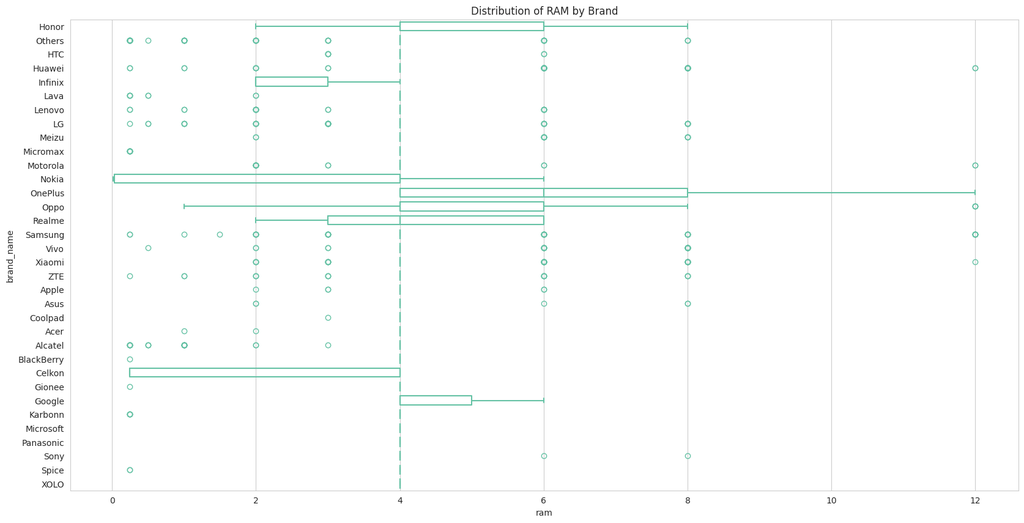

```python
# boxplot for ram by brand_name
sns.boxplot(x=df['ram'], y=df['brand_name'], fill=False, gap=.2)
plt.xlabel('ram')
plt.ylabel('brand_name')
plt.title('Distribution of RAM by Brand')
#Increase height of graph
plt.rcParams['figure.figsize'] = [20, 10]
#Color code brand_name
sns.set_palette('Set2')
plt.show()
```

A3: The amount of ram varies differently across all brands. OnePlus shows the highest amount of variance, while 3 brands have 0 variance. Most brands have an average ram near 4GB. Only 6 brands offer more than 8GB.

Q4: A large battery often increases a device's weight, making it feel uncomfortable in the hands. How does the weight vary for phones and tablets offering large batteries (more than 4500 mAh)?

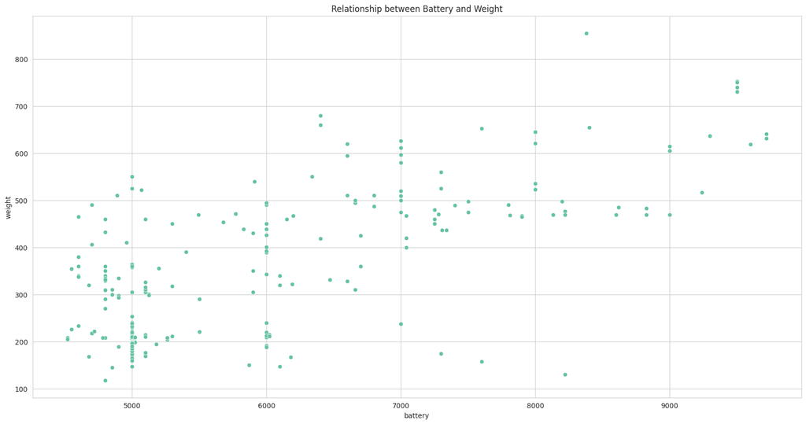

```python
# Create a new df for batteries greater than 4500
battery_4500 = df[df['battery'] > 4500]
# Graph the relationship between batteries over 4500 and weight
sns.scatterplot(x=battery_4500['battery'], y=battery_4500['weight'])
plt.xlabel('battery')
plt.ylabel('weight')
plt.title('Relationship between Battery and Weight')
plt.show()
```

A4: Weight tends to increase as battery mAh increases, showing a positive relationship between large batteries and weight of the device. There are a few outliers to the trendline.

Q5: Bigger screens are desirable for entertainment purposes as they offer a better viewing experience. How many phones and tablets are available across different brands with a screen size larger than 6 inches?

```python
# Create a new df with screen size greater than 6
screen_size_6 = df[df['screen_size'] > 6]
# Show the count of how many phones and tablets that have a screen size greater than 6 by brand
screen_size_6.groupby('brand_name')['screen_size'].count()
```

| brand_name | screen_size |
| --- | --- |
| Acer | 51 |
| Alcatel | 115 |
| Apple | 39 |
| Asus | 122 |
| BlackBerry | 21 |
| Celkon | 25 |
| Coolpad | 22 |
| Gionee | 56 |
| Google | 15 |
| HTC | 110 |
| Honor | 116 |
| Huawei | 251 |
| Infinix | 10 |
| Karbonn | 29 |
| LG | 197 |
| Lava | 36 |
| Lenovo | 171 |
| Meizu | 62 |
| Micromax | 108 |
| Microsoft | 22 |
| Motorola | 106 |
| Nokia | 72 |
| OnePlus | 22 |
| Oppo | 129 |
| Others | 479 |
| Panasonic | 47 |
| Realme | 41 |
| Samsung | 334 |
| Sony | 86 |
| Spice | 30 |
| Vivo | 117 |
| XOLO | 49 |
| Xiaomi | 132 |
| ZTE | 140 |

**dtype:** int64

```python
# Total number of screen sizes greater than 6
screen_size_6['screen_size'].count()
```

```
3362
```

Q6: A lot of devices nowadays offer great selfie cameras, allowing us to capture our favorite moments with loved ones. What is the distribution of devices offering greater than 8MP selfie cameras across brands?

```python
# Create a new df with selfie camera greater than 8
selfie_camera_8 = df[df['selfie_camera_mp'] > 8]
```

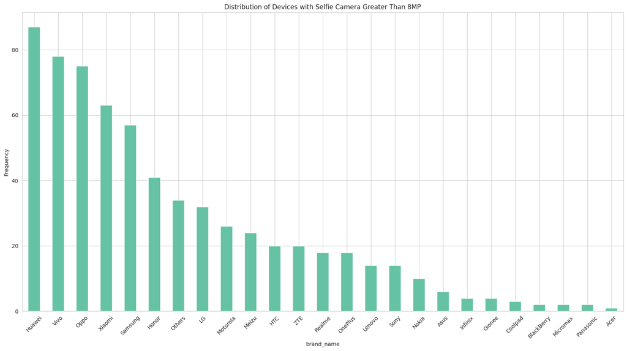

```python
# Histogram of devices across all brands with selfie camera greater than 8 by count
selfie_camera_8['brand_name'].value_counts().plot(kind='bar')
plt.xlabel('brand_name')
plt.ylabel('Frequency')
plt.title('Distribution of Devices with Selfie Camera Greater Than 8MP')
plt.xticks(rotation=45)
plt.show()
```

A6: The distribution of devices with a selfie camera over 8 MP varies across the brands. Huawei offers the most devices with this attribute.

Q7: Which attributes are highly correlated with the normalized price of a used device?

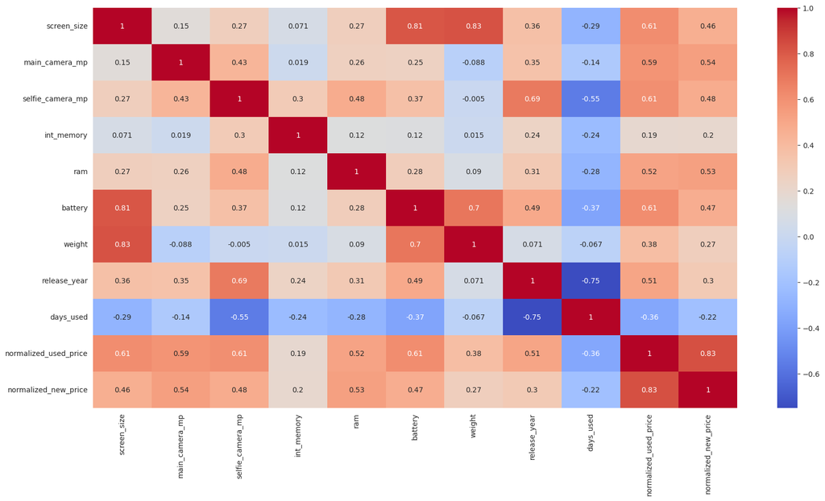

```python
# Create a new df with only numerical columns
df_num = df.select_dtypes(include=['int64', 'float64'])
# Heatmap of df_num
sns.heatmap(df_num.corr(), annot=True, cmap='coolwarm')
plt.show()
```

A7: Normalized used price is most correlated with normalized new price (0.83).

The next strongest correlations with used price are screen size (0.61), selfie camera mp (0.61), battery (0.61), and main camera mp (0.59).

## Data Preprocessing

- Missing value treatment
- Feature engineering (if needed)
- Outlier detection and treatment (if needed)
- Preparing data for modeling
- Any other preprocessing steps (if needed)

Missing value treatment

```python
# Check for missing values in df
df.isnull().sum()
```

|  | 0 |
| --- | --- |
| brand_name | 0 |
| os | 0 |
| screen_size | 0 |
| 4g | 0 |
| 5g | 0 |
| main_camera_mp | 179 |
| selfie_camera_mp | 2 |
| int_memory | 4 |
| ram | 4 |
| battery | 6 |
| weight | 7 |
| release_year | 0 |
| days_used | 0 |
| normalized_used_price | 0 |
| normalized_new_price | 0 |

**dtype:** int64

```python
# Let's replace the missing values with median values of the numerical columns.
# Every numerical column's missing value is replaced with that column's median respectively using the median filler lamda function
medianFiller = lambda x: x.fillna(x.median()) if pd.api.types.is_numeric_dtype(x) else x
df = df.apply(medianFiller, axis=0)
```

```python
df.info()
```

```
<class 'pandas.core.frame.DataFrame'>
RangeIndex: 3454 entries, 0 to 3453
Data columns (total 15 columns):
 #   Column                 Non-Null Count  Dtype
---  ------                 --------------  -----
 0   brand_name             3454 non-null   object
 1   os                     3454 non-null   object
 2   screen_size            3454 non-null   float64
 3   4g                     3454 non-null   object
 4   5g                     3454 non-null   object
 5   main_camera_mp         3454 non-null   float64
 6   selfie_camera_mp       3454 non-null   float64
 7   int_memory             3454 non-null   float64
 8   ram                    3454 non-null   float64
 9   battery                3454 non-null   float64
 10  weight                 3454 non-null   float64
 11  release_year           3454 non-null   int64
 12  days_used              3454 non-null   int64
 13  normalized_used_price  3454 non-null   float64
 14  normalized_new_price   3454 non-null   float64
dtypes: float64(9), int64(2), object(4)
memory usage: 404.9+ KB
```

```python
df.isnull().sum()
```

|  | 0 |
| --- | --- |
| brand_name | 0 |
| os | 0 |
| screen_size | 0 |
| 4g | 0 |
| 5g | 0 |
| main_camera_mp | 0 |
| selfie_camera_mp | 0 |
| int_memory | 0 |
| ram | 0 |
| battery | 0 |
| weight | 0 |
| release_year | 0 |
| days_used | 0 |
| normalized_used_price | 0 |
| normalized_new_price | 0 |

**dtype:** int64

Missing numerical data has been treated with the median of that column. No columns are missing data now.

```python
# Check df for outliers
df.describe().T
```

|  | count | mean | std | min | 25% | 50% | 75% | max |
| --- | --- | --- | --- | --- | --- | --- | --- | --- |
| screen_size | 3454.0 | 13.713115 | 3.805280 | 5.080000 | 12.700000 | 12.830000 | 15.340000 | 30.710000 |
| main_camera_mp | 3454.0 | 9.384534 | 4.700148 | 0.080000 | 5.000000 | 8.000000 | 13.000000 | 48.000000 |
| selfie_camera_mp | 3454.0 | 6.553329 | 6.968453 | 0.000000 | 2.000000 | 5.000000 | 8.000000 | 32.000000 |
| int_memory | 3454.0 | 54.546957 | 84.926611 | 0.010000 | 16.000000 | 32.000000 | 64.000000 | 1024.000000 |
| ram | 3454.0 | 4.036080 | 1.364314 | 0.020000 | 4.000000 | 4.000000 | 4.000000 | 12.000000 |
| battery | 3454.0 | 3133.170961 | 1298.565062 | 500.000000 | 2100.000000 | 3000.000000 | 4000.000000 | 9720.000000 |
| weight | 3454.0 | 182.705761 | 88.329494 | 69.000000 | 142.000000 | 160.000000 | 185.000000 | 855.000000 |
| release_year | 3454.0 | 2015.965258 | 2.298455 | 2013.000000 | 2014.000000 | 2015.500000 | 2018.000000 | 2020.000000 |
| days_used | 3454.0 | 674.869716 | 248.580166 | 91.000000 | 533.500000 | 690.500000 | 868.750000 | 1094.000000 |
| normalized_used_price | 3454.0 | 4.364712 | 0.588914 | 1.536867 | 4.033931 | 4.405133 | 4.755700 | 6.619433 |
| normalized_new_price | 3454.0 | 5.233107 | 0.683637 | 2.901422 | 4.790342 | 5.245892 | 5.673718 | 7.847841 |

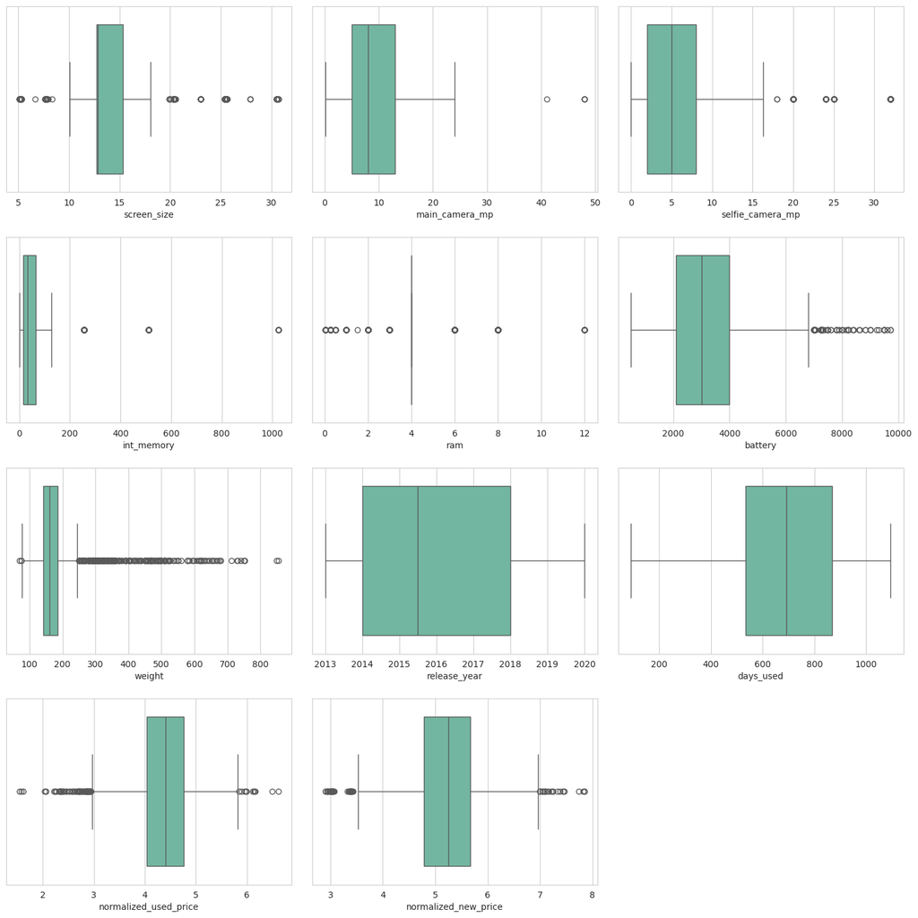

```python
# outlier detection using boxplot
num_cols = df.select_dtypes(include=np.number).columns.tolist()

plt.figure(figsize=(15, 15))

for i, variable in enumerate(num_cols):
    plt.subplot(4, 3, i + 1)
    sns.boxplot(data=df, x=variable)
    plt.tight_layout(pad=2)

plt.show()
```

There is a presence of some outliers, but we will proceed with them to keep the data in our df.

#### Preparing the data model building and Feature Engineering.

We will drop brand_name for prediction purposes

```python
# drop brand_name in df
df = df.drop('brand_name', axis=1)
```

```python
df.info()
```

```
<class 'pandas.core.frame.DataFrame'>
RangeIndex: 3454 entries, 0 to 3453
Data columns (total 14 columns):
 #   Column                 Non-Null Count  Dtype
---  ------                 --------------  -----
 0   os                     3454 non-null   object
 1   screen_size            3454 non-null   float64
 2   4g                     3454 non-null   object
 3   5g                     3454 non-null   object
 4   main_camera_mp         3454 non-null   float64
 5   selfie_camera_mp       3454 non-null   float64
 6   int_memory             3454 non-null   float64
 7   ram                    3454 non-null   float64
 8   battery                3454 non-null   float64
 9   weight                 3454 non-null   float64
 10  release_year           3454 non-null   int64
 11  days_used              3454 non-null   int64
 12  normalized_used_price  3454 non-null   float64
 13  normalized_new_price   3454 non-null   float64
dtypes: float64(9), int64(2), object(3)
memory usage: 377.9+ KB
```

```python
# Add a new column for device age (this data is from 2021)
df['device_age'] = 2021 - df['release_year']
# Remove years_used from df
df = df.drop('release_year', axis=1)
df.head()
```

|  | os | screen_size | 4g | 5g | main_camera_mp | selfie_camera_mp | int_memory | ram | battery | weight | days_used | normalized_used_price | normalized_new_price | device_age |
| --- | --- | --- | --- | --- | --- | --- | --- | --- | --- | --- | --- | --- | --- | --- |
| 0 | Android | 14.50 | yes | no | 13.0 | 5.0 | 64.0 | 3.0 | 3020.0 | 146.0 | 127 | 4.307572 | 4.715100 | 1 |
| 1 | Android | 17.30 | yes | yes | 13.0 | 16.0 | 128.0 | 8.0 | 4300.0 | 213.0 | 325 | 5.162097 | 5.519018 | 1 |
| 2 | Android | 16.69 | yes | yes | 13.0 | 8.0 | 128.0 | 8.0 | 4200.0 | 213.0 | 162 | 5.111084 | 5.884631 | 1 |
| 3 | Android | 25.50 | yes | yes | 13.0 | 8.0 | 64.0 | 6.0 | 7250.0 | 480.0 | 345 | 5.135387 | 5.630961 | 1 |
| 4 | Android | 15.32 | yes | no | 13.0 | 8.0 | 64.0 | 3.0 | 5000.0 | 185.0 | 293 | 4.389995 | 4.947837 | 1 |

We need to deal the object columns so we can use them in our model.

First we will create dummy variables for the column 'os'. We will also be dropping one of those four columns to ensure there is no linear dependency between the four columns.

```python
# Create dummy variables for column os in df
df = pd.get_dummies(df, columns=["os"], drop_first=True)
df.head()
```

|  | screen_size | 4g | 5g | main_camera_mp | selfie_camera_mp | int_memory | ram | battery | weight | days_used | normalized_used_price | normalized_new_price | device_age | os_Others | os_Windows | os_iOS |
| --- | --- | --- | --- | --- | --- | --- | --- | --- | --- | --- | --- | --- | --- | --- | --- | --- |
| 0 | 14.50 | yes | no | 13.0 | 5.0 | 64.0 | 3.0 | 3020.0 | 146.0 | 127 | 4.307572 | 4.715100 | 1 | False | False | False |
| 1 | 17.30 | yes | yes | 13.0 | 16.0 | 128.0 | 8.0 | 4300.0 | 213.0 | 325 | 5.162097 | 5.519018 | 1 | False | False | False |
| 2 | 16.69 | yes | yes | 13.0 | 8.0 | 128.0 | 8.0 | 4200.0 | 213.0 | 162 | 5.111084 | 5.884631 | 1 | False | False | False |
| 3 | 25.50 | yes | yes | 13.0 | 8.0 | 64.0 | 6.0 | 7250.0 | 480.0 | 345 | 5.135387 | 5.630961 | 1 | False | False | False |
| 4 | 15.32 | yes | no | 13.0 | 8.0 | 64.0 | 3.0 | 5000.0 | 185.0 | 293 | 4.389995 | 4.947837 | 1 | False | False | False |

```python
#Change os columns data output of true false to 1,0
df = df.replace({True: 1, False: 0})
df.head()
```

|  | screen_size | 4g | 5g | main_camera_mp | selfie_camera_mp | int_memory | ram | battery | weight | days_used | normalized_used_price | normalized_new_price | device_age | os_Others | os_Windows | os_iOS |
| --- | --- | --- | --- | --- | --- | --- | --- | --- | --- | --- | --- | --- | --- | --- | --- | --- |
| 0 | 14.50 | yes | no | 13.0 | 5.0 | 64.0 | 3.0 | 3020.0 | 146.0 | 127 | 4.307572 | 4.715100 | 1 | 0 | 0 | 0 |
| 1 | 17.30 | yes | yes | 13.0 | 16.0 | 128.0 | 8.0 | 4300.0 | 213.0 | 325 | 5.162097 | 5.519018 | 1 | 0 | 0 | 0 |
| 2 | 16.69 | yes | yes | 13.0 | 8.0 | 128.0 | 8.0 | 4200.0 | 213.0 | 162 | 5.111084 | 5.884631 | 1 | 0 | 0 | 0 |
| 3 | 25.50 | yes | yes | 13.0 | 8.0 | 64.0 | 6.0 | 7250.0 | 480.0 | 345 | 5.135387 | 5.630961 | 1 | 0 | 0 | 0 |
| 4 | 15.32 | yes | no | 13.0 | 8.0 | 64.0 | 3.0 | 5000.0 | 185.0 | 293 | 4.389995 | 4.947837 | 1 | 0 | 0 | 0 |

```python
#Change 4g and 5g columns data output of yes no to 1,0
df = df.replace({'yes': 1, 'no': 0})
df.head()
```

|  | screen_size | 4g | 5g | main_camera_mp | selfie_camera_mp | int_memory | ram | battery | weight | days_used | normalized_used_price | normalized_new_price | device_age | os_Others | os_Windows | os_iOS |
| --- | --- | --- | --- | --- | --- | --- | --- | --- | --- | --- | --- | --- | --- | --- | --- | --- |
| 0 | 14.50 | 1 | 0 | 13.0 | 5.0 | 64.0 | 3.0 | 3020.0 | 146.0 | 127 | 4.307572 | 4.715100 | 1 | 0 | 0 | 0 |
| 1 | 17.30 | 1 | 1 | 13.0 | 16.0 | 128.0 | 8.0 | 4300.0 | 213.0 | 325 | 5.162097 | 5.519018 | 1 | 0 | 0 | 0 |
| 2 | 16.69 | 1 | 1 | 13.0 | 8.0 | 128.0 | 8.0 | 4200.0 | 213.0 | 162 | 5.111084 | 5.884631 | 1 | 0 | 0 | 0 |
| 3 | 25.50 | 1 | 1 | 13.0 | 8.0 | 64.0 | 6.0 | 7250.0 | 480.0 | 345 | 5.135387 | 5.630961 | 1 | 0 | 0 | 0 |
| 4 | 15.32 | 1 | 0 | 13.0 | 8.0 | 64.0 | 3.0 | 5000.0 | 185.0 | 293 | 4.389995 | 4.947837 | 1 | 0 | 0 | 0 |

```python
df.info()
```

```
<class 'pandas.core.frame.DataFrame'>
RangeIndex: 3454 entries, 0 to 3453
Data columns (total 16 columns):
 #   Column                 Non-Null Count  Dtype
---  ------                 --------------  -----
 0   screen_size            3454 non-null   float64
 1   4g                     3454 non-null   int64
 2   5g                     3454 non-null   int64
 3   main_camera_mp         3454 non-null   float64
 4   selfie_camera_mp       3454 non-null   float64
 5   int_memory             3454 non-null   float64
 6   ram                    3454 non-null   float64
 7   battery                3454 non-null   float64
 8   weight                 3454 non-null   float64
 9   days_used              3454 non-null   int64
 10  normalized_used_price  3454 non-null   float64
 11  normalized_new_price   3454 non-null   float64
 12  device_age             3454 non-null   int64
 13  os_Others              3454 non-null   int64
 14  os_Windows             3454 non-null   int64
 15  os_iOS                 3454 non-null   int64
dtypes: float64(9), int64(7)
memory usage: 431.9 KB
```

We have no missing values and all categorical variables have been displayed as numerical values for analysis and model building.

## EDA

- It is a good idea to explore the data once again after manipulating it.

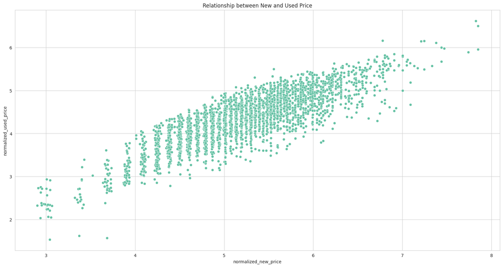

```python
# Display relationship of new device cost versus used device cost
sns.scatterplot(x=df['normalized_new_price'], y=df['normalized_used_price'])
plt.xlabel('normalized_new_price')
plt.ylabel('normalized_used_price')
plt.title('Relationship between New and Used Price')
```

New price and used price show evidence of a strong positive linear relationship.

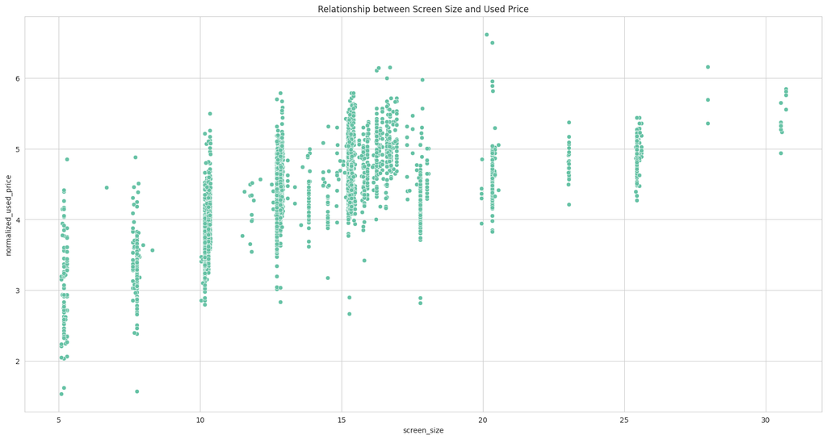

```python
# Display used cost versus screen size
sns.scatterplot(x=df['screen_size'], y=df['normalized_used_price'])
plt.xlabel('screen_size')
plt.ylabel('normalized_used_price')
plt.title('Relationship between Screen Size and Used Price')
plt.show()
```

Increasing screen size shows to correlate with increasing used device price

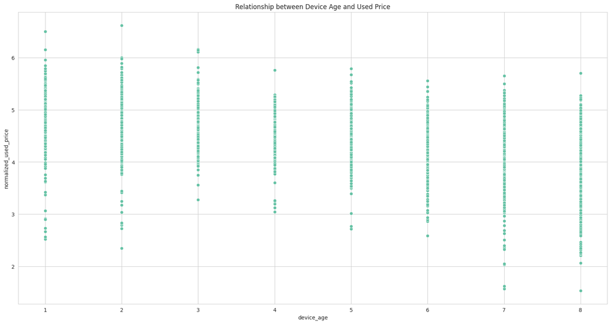

```python
# Show device age versus used device cost
sns.scatterplot(x=df['device_age'], y=df['normalized_used_price'])
plt.xlabel('device_age')
plt.ylabel('normalized_used_price')
plt.title('Relationship between Device Age and Used Price')
plt.show()
```

We can see a trend that as age of the device increases, cost of the used device decreases.

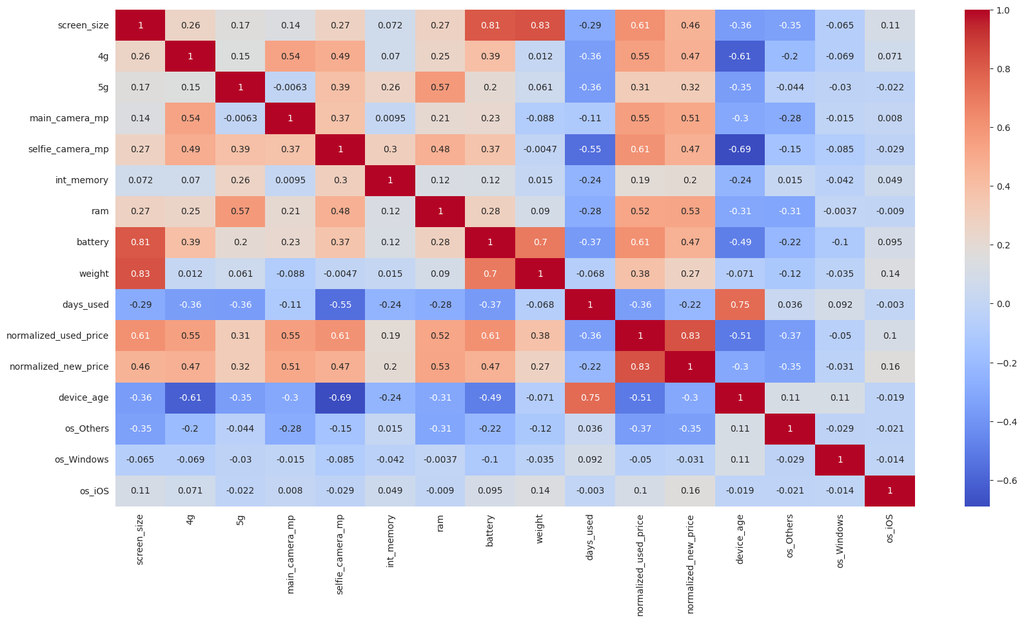

```python
# heatmap for df
sns.heatmap(df.corr(), annot=True, cmap='coolwarm')
plt.show()
```

We can see that the strongest positive correlation for used price is still new price.

Used price also has positive correlations with screen size, selfie camera mp, and battery.

Battery and weight both positively correlate with screen size.

Used price has a slight negative correlation with os_others and days used.

Selfie camera mp has a positive correlation with release year and a negative correlation with days used.

## Model Building - Linear Regression

```python
# Define our independent variables and dependent variable in df
# Our dependent variable will be normalized used price
X = df.drop('normalized_used_price', axis=1)
y = df['normalized_used_price']
```

```python
# let's add the intercept to data
X = sm.add_constant(X)
```

We will now split X and y into train and test sets in a 70:30 ratio.

```python
X_train, X_test, y_train, y_test = train_test_split(
    X, y, test_size=0.30, random_state=1
)
```

```python
print(X_train.head())
```

```
      const  screen_size  4g  5g  main_camera_mp  selfie_camera_mp  \
3026    1.0        10.29   0   0             8.0               0.3
1525    1.0        15.34   1   0            13.0               5.0
1128    1.0        12.70   0   0            13.0               5.0
3003    1.0        12.83   1   0             8.0               5.0
2907    1.0        12.88   1   0            13.0              16.0

      int_memory  ram  battery  weight  days_used  normalized_new_price  \
3026        16.0  4.0   1800.0   120.0        819              4.796204
1525        32.0  4.0   4050.0   225.0        585              5.434595
1128        32.0  4.0   2550.0   162.0        727              5.137914
3003        16.0  4.0   3200.0   160.0        800              5.189228
2907        16.0  4.0   2900.0   160.0        560              5.016220

      device_age  os_Others  os_Windows  os_iOS
3026           7          0           0       0
1525           5          0           0       0
1128           6          0           0       0
3003           6          0           0       0
2907           4          0           0       0
```

```python
print(X_test.head())
```

```
      const  screen_size  4g  5g  main_camera_mp  selfie_camera_mp  \
866     1.0        15.24   0   0            8.00               2.0
957     1.0        10.16   0   0            3.15               0.3
280     1.0        15.39   1   0            8.00               8.0
2150    1.0        12.83   1   0           13.00              16.0
93      1.0        15.29   1   0           13.00               5.0

      int_memory   ram  battery  weight  days_used  normalized_new_price  \
866         16.0  4.00   3000.0   206.0        632              5.190788
957        512.0  0.25   1400.0   140.0        637              3.884652
280         32.0  2.00   5000.0   185.0        329              4.487287
2150        64.0  4.00   3200.0   148.0        648              5.639422
93          32.0  3.00   3500.0   179.0        216              5.300415

      device_age  os_Others  os_Windows  os_iOS
866            7          0           0       0
957            8          0           0       0
280            1          0           0       0
2150           4          0           0       0
93             2          0           0       0
```

Fit Linear Model

```python
olsmod = sm.OLS(y_train, X_train)
olsres = olsmod.fit()
```

```python
#Print the regression summary
print(olsres.summary())
```

```
                              OLS Regression Results
=================================================================================
Dep. Variable:     normalized_used_price   R-squared:                       0.841
Model:                               OLS   Adj. R-squared:                  0.840
Method:                    Least Squares   F-statistic:                     847.8
Date:                   Fri, 06 Sep 2024   Prob (F-statistic):               0.00
Time:                           21:37:30   Log-Likelihood:                 95.399
No. Observations:                   2417   AIC:                            -158.8
Df Residuals:                       2401   BIC:                            -66.15
Df Model:                             15
Covariance Type:               nonrobust
========================================================================================
                           coef    std err          t      P>|t|      [0.025      0.975]
----------------------------------------------------------------------------------------
const                    1.3958      0.053     26.219      0.000       1.291       1.500
screen_size              0.0251      0.003      7.551      0.000       0.019       0.032
4g                       0.0473      0.015      3.092      0.002       0.017       0.077
5g                      -0.0156      0.031     -0.500      0.617      -0.077       0.046
main_camera_mp           0.0204      0.001     14.513      0.000       0.018       0.023
selfie_camera_mp         0.0140      0.001     12.913      0.000       0.012       0.016
int_memory            9.026e-05    6.7e-05      1.347      0.178   -4.12e-05       0.000
ram                      0.0214      0.005      4.289      0.000       0.012       0.031
battery              -1.074e-05   7.09e-06     -1.515      0.130   -2.46e-05    3.16e-06
weight                   0.0009      0.000      7.021      0.000       0.001       0.001
days_used             3.729e-05   3.06e-05      1.219      0.223   -2.27e-05    9.73e-05
normalized_new_price     0.4202      0.011     36.935      0.000       0.398       0.443
device_age              -0.0270      0.004     -6.075      0.000      -0.036      -0.018
os_Others               -0.0537      0.029     -1.826      0.068      -0.111       0.004
os_Windows               0.0271      0.036      0.745      0.456      -0.044       0.098
os_iOS                  -0.0635      0.045     -1.420      0.156      -0.151       0.024
==============================================================================
Omnibus:                      219.770   Durbin-Watson:                   1.904
Prob(Omnibus):                  0.000   Jarque-Bera (JB):              413.839
Skew:                          -0.612   Prob(JB):                     1.37e-90
Kurtosis:                       4.616   Cond. No.                     4.12e+04
==============================================================================

Notes:
[1] Standard Errors assume that the covariance matrix of the errors is correctly specified.
[2] The condition number is large, 4.12e+04. This might indicate that there are
strong multicollinearity or other numerical problems.
```

#### Interpretation of R squared

The R-squared value tells us that our model can explain 84.1% of the variance in the training set.

#### Interpretation of Coefficients

- The coefficients tell us how one unit change in X can affect y.
- The sign of the coefficient indicates if the relationship is positive or negative.
- In this data set, for example, an increase of 1 unit of new price occurs with a 0.4202 increase in used price.
- Earlier we saw that the relationship of used price with battery, screen size and selfie camera mp is the same. This suggests that all the 3 factors have similar effect on used price, i.e., the increase in either of the 3 increases used price. Therefore, the signs of the coefficents should be the same. But we observe that it is not so. This indicates the presence of multicollinearity in our data.
- If the collinearity between variables is high, we might not be able to trust the p-values to identify independent variables that are statistically significant.

We need to ensure that there is no multicollinearity in order to interpret the p-values.

```python
# We will use the variance inflation factor to check for multicollinearity
# let's check the VIF of the predictors
from statsmodels.stats.outliers_influence import variance_inflation_factor

vif_series1 = pd.Series(
    [variance_inflation_factor(X_train.values, i) for i in range(X_train.shape[1])],
    index=X_train.columns,
)
print("VIF values: \n\n{}\n".format(vif_series1))
```

```
VIF values:

const                   125.768700
screen_size               7.257522
4g                        2.269786
5g                        1.762858
main_camera_mp            1.924868
selfie_camera_mp          2.572363
int_memory                1.247150
ram                       2.103621
battery                   3.835618
weight                    6.120544
days_used                 2.589619
normalized_new_price      2.658599
device_age                4.613026
os_Others                 1.475205
os_Windows                1.023196
os_iOS                    1.089057
dtype: float64
```

The VIF values >5 indicate that the features screen size and weight are correlated with one or more independent features.

To treat multicollinearity, we will have to drop one or more of the correlated features (screen size and weight).

We will drop the variable that has the least impact on the adjusted R-squared of the model.

```python
# Dropping screen size from training model
X_train2 = X_train.drop(["screen_size"], axis=1)
olsmod_1 = sm.OLS(y_train, X_train2)
olsres_1 = olsmod_1.fit()
print(
    "R-squared:",
    np.round(olsres_1.rsquared, 3),
    "\nAdjusted R-squared:",
    np.round(olsres_1.rsquared_adj, 3),
)
```

```
R-squared: 0.837
Adjusted R-squared: 0.836
```

```python
# Dropping weight from the training model
X_train3 = X_train.drop(["weight"], axis=1)
olsmod_2 = sm.OLS(y_train, X_train3)
olsres_2 = olsmod_2.fit()
print(
    "R-squared:",
    np.round(olsres_2.rsquared, 3),
    "\nAdjusted R-squared:",
    np.round(olsres_2.rsquared_adj, 3),
)
```

```
R-squared: 0.838
Adjusted R-squared: 0.837
```

Dropping weight had a slightly less effect on R-squared so we will drop weight and run the model again and check VIF again

```python
X_train = X_train.drop(["weight"], axis=1)
```

```python
olsmod_3 = sm.OLS(y_train, X_train)
olsres_3 = olsmod_3.fit()
print(olsres_3.summary())
```

```
                              OLS Regression Results
=================================================================================
Dep. Variable:     normalized_used_price   R-squared:                       0.838
Model:                               OLS   Adj. R-squared:                  0.837
Method:                    Least Squares   F-statistic:                     887.1
Date:                   Fri, 06 Sep 2024   Prob (F-statistic):               0.00
Time:                           21:37:30   Log-Likelihood:                 70.841
No. Observations:                   2417   AIC:                            -111.7
Df Residuals:                       2402   BIC:                            -24.83
Df Model:                             14
Covariance Type:               nonrobust
========================================================================================
                           coef    std err          t      P>|t|      [0.025      0.975]
----------------------------------------------------------------------------------------
const                    1.2565      0.050     25.183      0.000       1.159       1.354
screen_size              0.0422      0.002     18.369      0.000       0.038       0.047
4g                       0.0367      0.015      2.391      0.017       0.007       0.067
5g                      -0.0127      0.032     -0.403      0.687      -0.075       0.049
main_camera_mp           0.0183      0.001     13.218      0.000       0.016       0.021
selfie_camera_mp         0.0131      0.001     12.055      0.000       0.011       0.015
int_memory            8.352e-05   6.77e-05      1.234      0.217   -4.92e-05       0.000
ram                      0.0199      0.005      3.962      0.000       0.010       0.030
battery               4.751e-06    6.8e-06      0.698      0.485   -8.59e-06    1.81e-05
days_used              5.37e-05   3.08e-05      1.743      0.081   -6.72e-06       0.000
normalized_new_price     0.4240      0.011     36.933      0.000       0.401       0.446
device_age              -0.0210      0.004     -4.768      0.000      -0.030      -0.012
os_Others                0.0048      0.028      0.168      0.867      -0.051       0.061
os_Windows               0.0342      0.037      0.931      0.352      -0.038       0.106
os_iOS                  -0.0358      0.045     -0.795      0.427      -0.124       0.052
==============================================================================
Omnibus:                      208.532   Durbin-Watson:                   1.907
Prob(Omnibus):                  0.000   Jarque-Bera (JB):              378.169
Skew:                          -0.598   Prob(JB):                     7.62e-83
Kurtosis:                       4.525   Cond. No.                     3.89e+04
==============================================================================

Notes:
[1] Standard Errors assume that the covariance matrix of the errors is correctly specified.
[2] The condition number is large, 3.89e+04. This might indicate that there are
strong multicollinearity or other numerical problems.
```

```python
# let's check the VIF of the predictors
from statsmodels.stats.outliers_influence import variance_inflation_factor

vif_series1 = pd.Series(
    [variance_inflation_factor(X_train.values, i) for i in range(X_train.shape[1])],
    index=X_train.columns,
)
print("VIF values: \n\n{}\n".format(vif_series1))
```

```
VIF values:

const                   108.302548
screen_size               3.388518
4g                        2.247957
5g                        1.762548
main_camera_mp            1.842709
selfie_camera_mp          2.537169
int_memory                1.246894
ram                       2.100018
battery                   3.463821
days_used                 2.574507
normalized_new_price      2.652817
device_age                4.442759
os_Others                 1.356829
os_Windows                1.022405
os_iOS                    1.080561
dtype: float64
```

All VIF values are less than 5, showing that multicollinearity is not evident

### Now that we do not have multicollinearity in our data, the p-values of the coefficients have become reliable and we can remove the non-significant predictor variables.

p-values for dummy variables

```python
# We see that the p-values for all dummy variables are high so we will drop all 'os' features.
# Drop os_Others, os_Windows, and os_iOS
X_train = X_train.drop(["os_Others", "os_Windows", "os_iOS"], axis=1)
```

variables 5g, int memory, battery and days used have a p-value >.05 showing they are not statistically significant and will be dropped.

```python
#drop features 5g, int_memory, battery, and days_used from the model
X_train = X_train.drop(["5g", "int_memory", "battery", "days_used"], axis=1)
```

## Model Performance Check

```python
olsmod_4 = sm.OLS(y_train, X_train)
olsres_4 = olsmod_4.fit()
print(olsres_4.summary())
```

```
                              OLS Regression Results
=================================================================================
Dep. Variable:     normalized_used_price   R-squared:                       0.837
Model:                               OLS   Adj. R-squared:                  0.837
Method:                    Least Squares   F-statistic:                     1774.
Date:                   Fri, 06 Sep 2024   Prob (F-statistic):               0.00
Time:                           21:37:30   Log-Likelihood:                 67.613
No. Observations:                   2417   AIC:                            -119.2
Df Residuals:                       2409   BIC:                            -72.90
Df Model:                              7
Covariance Type:               nonrobust
========================================================================================
                           coef    std err          t      P>|t|      [0.025      0.975]
----------------------------------------------------------------------------------------
const                    1.2790      0.045     28.656      0.000       1.191       1.367
screen_size              0.0431      0.001     28.743      0.000       0.040       0.046
4g                       0.0384      0.015      2.558      0.011       0.009       0.068
main_camera_mp           0.0186      0.001     14.204      0.000       0.016       0.021
selfie_camera_mp         0.0132      0.001     12.468      0.000       0.011       0.015
ram                      0.0186      0.004      4.293      0.000       0.010       0.027
normalized_new_price     0.4242      0.011     39.297      0.000       0.403       0.445
device_age              -0.0170      0.003     -4.979      0.000      -0.024      -0.010
==============================================================================
Omnibus:                      209.538   Durbin-Watson:                   1.909
Prob(Omnibus):                  0.000   Jarque-Bera (JB):              390.486
Skew:                          -0.591   Prob(JB):                     1.61e-85
Kurtosis:                       4.574   Cond. No.                         193.
==============================================================================

Notes:
[1] Standard Errors assume that the covariance matrix of the errors is correctly specified.
```

Our model has improved based on almost no change in R-squared, and all non dummy variables have a very significant p-value.

Checking VIF again:

```python
vif_series1 = pd.Series(
    [variance_inflation_factor(X_train.values, i) for i in range(X_train.shape[1])],
    index=X_train.columns,
)
print("VIF values: \n\n{}\n".format(vif_series1))
```

```
VIF values:

const                   86.678520
screen_size              1.442553
4g                       2.144659
main_camera_mp           1.645803
selfie_camera_mp         2.419293
ram                      1.565387
normalized_new_price     2.346849
device_age               2.673335
dtype: float64
```

All VIF values are < 5. This shows evidence against multicollinearity

## Checking Linear Regression Assumptions

- In order to make statistical inferences from a linear regression model, it is important to ensure that the assumptions of linear regression are satisfied.

Test for linearity and independence

```python
df_pred = pd.DataFrame()

df_pred["Actual Values"] = y_train.values.flatten()  # actual values
df_pred["Fitted Values"] = olsres_4.fittedvalues.values  # predicted values
df_pred["Residuals"] = olsres_4.resid.values  # residuals

df_pred.head()
```

|  | Actual Values | Fitted Values | Residuals |
| --- | --- | --- | --- |
| 0 | 4.087488 | 3.865253 | 0.222235 |
| 1 | 4.448399 | 4.581051 | -0.132651 |
| 2 | 4.315353 | 4.286071 | 0.029282 |
| 3 | 4.282068 | 4.258824 | 0.023244 |
| 4 | 4.456438 | 4.459768 | -0.003330 |

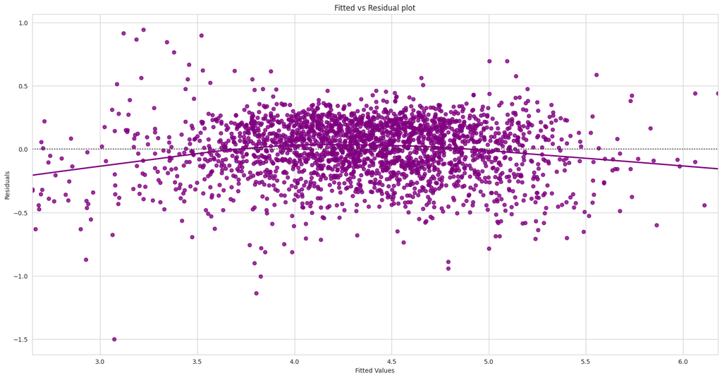

```python
# let us plot the fitted values vs residuals
sns.set_style("whitegrid")
sns.residplot(
    data=df_pred, x="Fitted Values", y="Residuals", color="purple", lowess=True
)
plt.xlabel("Fitted Values")
plt.ylabel("Residuals")
plt.title("Fitted vs Residual plot")
plt.show()
```

The residuals are almost linear, lets see if we can improve it by transforming some of the features.

```python
# columns in training set
X_train.columns
```

```
Index(['const', 'screen_size', '4g', 'main_camera_mp', 'selfie_camera_mp',
       'ram', 'normalized_new_price', 'device_age'],
      dtype='object')
```

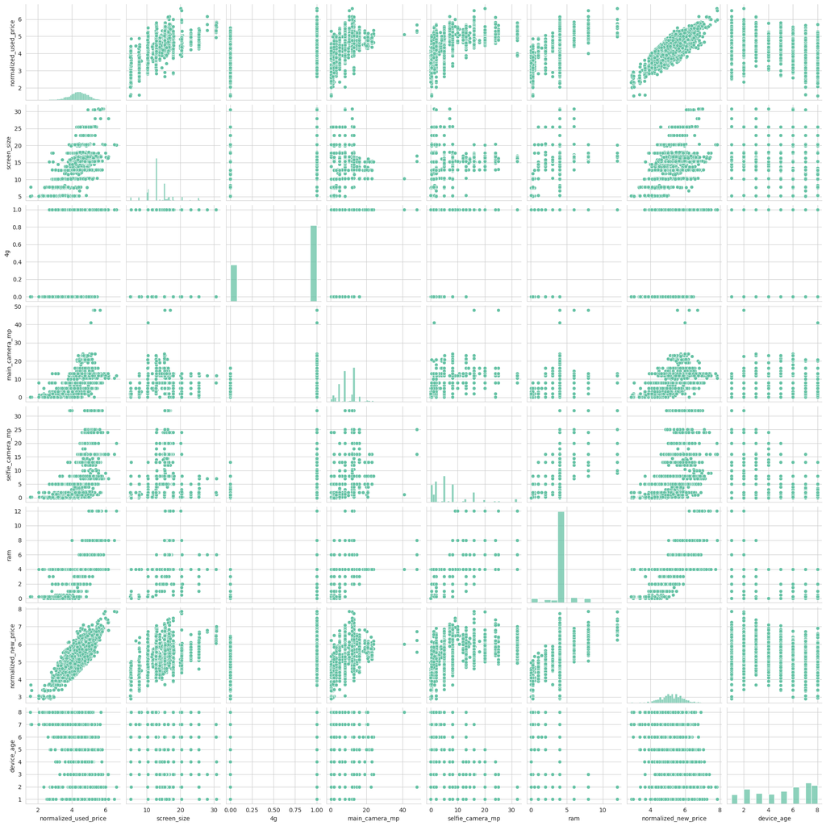

```python
# checking the distribution of variables in training set with dependent variable
sns.pairplot(df[['normalized_used_price','screen_size', '4g', 'main_camera_mp', 'selfie_camera_mp',
       'ram', 'normalized_new_price', 'device_age', ]])
plt.show()
```

Selfie camera mp and main camera mp are slightly not linear with used cost, so we will transform those using square transformation

```python
# using square transformation
X_train["main_camera_mp_sq"] = np.square(X_train["main_camera_mp"])
X_train['selfie_camera_mp_sq'] = np.square(X_train['selfie_camera_mp'])
# let's create a model with the transformed data
olsmod_5 = sm.OLS(y_train, X_train)
olsres_5 = olsmod_5.fit()
print(olsres_5.summary())
```

```
                              OLS Regression Results
=================================================================================
Dep. Variable:     normalized_used_price   R-squared:                       0.839
Model:                               OLS   Adj. R-squared:                  0.839
Method:                    Least Squares   F-statistic:                     1397.
Date:                   Fri, 06 Sep 2024   Prob (F-statistic):               0.00
Time:                           21:37:54   Log-Likelihood:                 80.980
No. Observations:                   2417   AIC:                            -142.0
Df Residuals:                       2407   BIC:                            -84.06
Df Model:                              9
Covariance Type:               nonrobust
========================================================================================
                           coef    std err          t      P>|t|      [0.025      0.975]
----------------------------------------------------------------------------------------
const                    1.2574      0.045     28.105      0.000       1.170       1.345
screen_size              0.0436      0.001     29.164      0.000       0.041       0.047
4g                       0.0237      0.015      1.556      0.120      -0.006       0.053
main_camera_mp           0.0256      0.003      9.662      0.000       0.020       0.031
selfie_camera_mp         0.0216      0.003      7.042      0.000       0.016       0.028
ram                      0.0195      0.004      4.488      0.000       0.011       0.028
normalized_new_price     0.4119      0.011     37.394      0.000       0.390       0.433
device_age              -0.0123      0.004     -3.295      0.001      -0.020      -0.005
main_camera_mp_sq       -0.0003   8.26e-05     -3.803      0.000      -0.000      -0.000
selfie_camera_mp_sq     -0.0003    8.9e-05     -2.896      0.004      -0.000   -8.33e-05
==============================================================================
Omnibus:                      196.763   Durbin-Watson:                   1.920
Prob(Omnibus):                  0.000   Jarque-Bera (JB):              376.659
Skew:                          -0.553   Prob(JB):                     1.62e-82
Kurtosis:                       4.586   Cond. No.                     2.22e+03
==============================================================================

Notes:
[1] Standard Errors assume that the covariance matrix of the errors is correctly specified.
[2] The condition number is large, 2.22e+03. This might indicate that there are
strong multicollinearity or other numerical problems.
```

```python
df_pred = pd.DataFrame()

df_pred["Actual Values"] = y_train.values.flatten()  # actual values
df_pred["Fitted Values"] = olsres_5.fittedvalues.values  # predicted values
df_pred["Residuals"] = olsres_5.resid.values  # residuals

df_pred.head()
```

|  | Actual Values | Fitted Values | Residuals |
| --- | --- | --- | --- |
| 0 | 4.087488 | 3.864214 | 0.223274 |
| 1 | 4.448399 | 4.585802 | -0.137403 |
| 2 | 4.315353 | 4.312512 | 0.002841 |
| 3 | 4.282068 | 4.267881 | 0.014187 |
| 4 | 4.456438 | 4.496519 | -0.040081 |

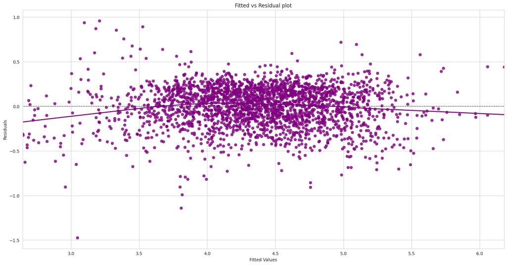

```python
# let us plot the fitted values vs residuals
sns.set_style("whitegrid")
sns.residplot(
    data=df_pred, x="Fitted Values", y="Residuals", color="purple", lowess=True
)
plt.xlabel("Fitted Values")
plt.ylabel("Residuals")
plt.title("Fitted vs Residual plot")
plt.show()
```

Our model slightly improved, so we can use it and move on to normality testing.

Check for normality of residuals

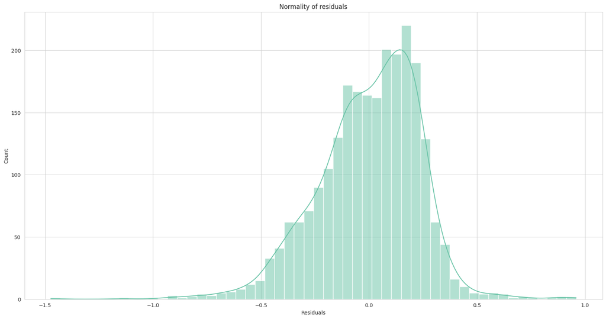

```python
sns.histplot(df_pred["Residuals"], kde=True)
plt.title("Normality of residuals")
plt.show()
```

Although our data is slightly skewed left, it is close to a normal shape.

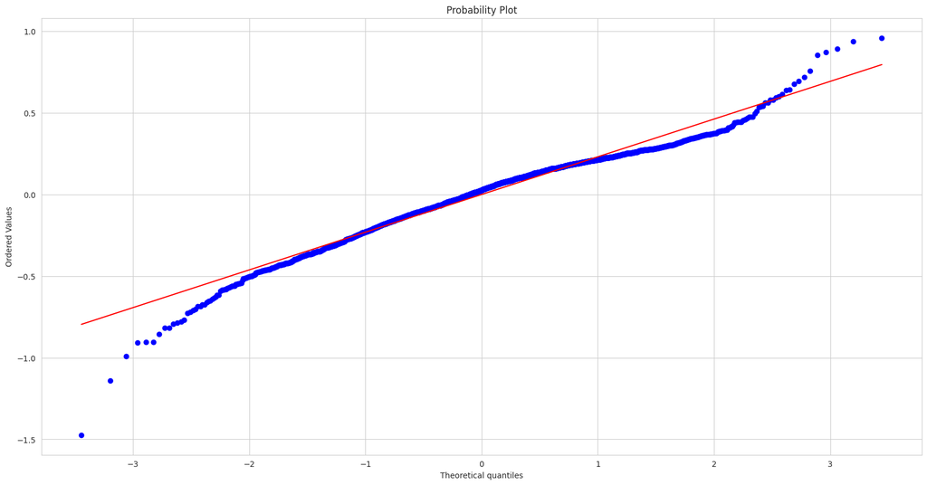

```python
import pylab
import scipy.stats as stats

stats.probplot(df_pred["Residuals"], dist="norm", plot=pylab)
plt.show()
```

Most of our data lies along the line, with some error near the tails.

Perform the Shapiro Test for normality of residuals

```python
stats.shapiro(df_pred["Residuals"])
```

```
ShapiroResult(statistic=0.9733921512097686, pvalue=8.371764563897158e-21)
```

Since p-value < 0.05, the residuals are not normal as per shapiro test. However, as an approximation, we might be willing to accept this distribution as close to being normal

Test for Homoscedasticity using the Goldfeldquandt test

The null and alternate hypotheses of the goldfeldquandt test are as follows:

Null hypothesis : Residuals are homoscedastic Alternate hypothesis : Residuals have hetroscedasticity

```python
import statsmodels.stats.api as sms
from statsmodels.compat import lzip
```

```python
name = ["F statistic", "p-value"]
test = sms.het_goldfeldquandt(df_pred["Residuals"], X_train)
lzip(name, test)
```

```
[('F statistic', 1.0579922063867473), ('p-value', 0.16464582178683682)]
```

We get p-value > 0.05 we can say that the residuals are homoscedastic

## Final Model

```python
# Show final model
print(olsres_5.summary())
```

```
                              OLS Regression Results
=================================================================================
Dep. Variable:     normalized_used_price   R-squared:                       0.839
Model:                               OLS   Adj. R-squared:                  0.839
Method:                    Least Squares   F-statistic:                     1397.
Date:                   Fri, 06 Sep 2024   Prob (F-statistic):               0.00
Time:                           21:37:56   Log-Likelihood:                 80.980
No. Observations:                   2417   AIC:                            -142.0
Df Residuals:                       2407   BIC:                            -84.06
Df Model:                              9
Covariance Type:               nonrobust
========================================================================================
                           coef    std err          t      P>|t|      [0.025      0.975]
----------------------------------------------------------------------------------------
const                    1.2574      0.045     28.105      0.000       1.170       1.345
screen_size              0.0436      0.001     29.164      0.000       0.041       0.047
4g                       0.0237      0.015      1.556      0.120      -0.006       0.053
main_camera_mp           0.0256      0.003      9.662      0.000       0.020       0.031
selfie_camera_mp         0.0216      0.003      7.042      0.000       0.016       0.028
ram                      0.0195      0.004      4.488      0.000       0.011       0.028
normalized_new_price     0.4119      0.011     37.394      0.000       0.390       0.433
device_age              -0.0123      0.004     -3.295      0.001      -0.020      -0.005
main_camera_mp_sq       -0.0003   8.26e-05     -3.803      0.000      -0.000      -0.000
selfie_camera_mp_sq     -0.0003    8.9e-05     -2.896      0.004      -0.000   -8.33e-05
==============================================================================
Omnibus:                      196.763   Durbin-Watson:                   1.920
Prob(Omnibus):                  0.000   Jarque-Bera (JB):              376.659
Skew:                          -0.553   Prob(JB):                     1.62e-82
Kurtosis:                       4.586   Cond. No.                     2.22e+03
==============================================================================

Notes:
[1] Standard Errors assume that the covariance matrix of the errors is correctly specified.
[2] The condition number is large, 2.22e+03. This might indicate that there are
strong multicollinearity or other numerical problems.
```

Observations R-squared of the model is 0.839 and adjusted R-squared is 0.839, which shows that the model is able to explain ~84% variance in the data. This is good.

A unit increase in the new device price will result in a 0.4119 unit increase in the used device's price, all other variables remaining constant.

Coefficients of our independent variables

```python
#Check the model parameters
olsres_5.params
```

|  | 0 |
| --- | --- |
| const | 1.257434 |
| screen_size | 0.043592 |
| 4g | 0.023663 |
| main_camera_mp | 0.025616 |
| selfie_camera_mp | 0.021591 |
| ram | 0.019467 |
| normalized_new_price | 0.411885 |
| device_age | -0.012345 |
| main_camera_mp_sq | -0.000314 |
| selfie_camera_mp_sq | -0.000258 |

**dtype:** float64

```python
# Write the equation for linear regression
Equation = "normalized_used_price ="
print(Equation, end=" ")
for i in range(len(X_train.columns)):
    if i == 0:
        print(olsres_5.params[i], "+", end=" ")
    elif i != len(X_train.columns) - 1:
        print(
            olsres_5.params[i],
            "* (",
            X_train.columns[i],
            ")",
            "+",
            end="  ",
        )
    else:
        print(olsres_5.params[i], "* (", X_train.columns[i], ")")
```

[output not shown]

```python
X_train.columns
```

```
Index(['const', 'screen_size', '4g', 'main_camera_mp', 'selfie_camera_mp',
       'ram', 'normalized_new_price', 'device_age', 'main_camera_mp_sq',
       'selfie_camera_mp_sq'],
      dtype='object')
```

```python
X_test.columns
```

```
Index(['const', 'screen_size', '4g', '5g', 'main_camera_mp',
       'selfie_camera_mp', 'int_memory', 'ram', 'battery', 'weight',
       'days_used', 'normalized_new_price', 'device_age', 'os_Others',
       'os_Windows', 'os_iOS'],
      dtype='object')
```

```python
# Drop columns in test data to correspond with train data
X_test = X_test.drop(["5g", "int_memory", "battery", "days_used", "weight"], axis=1)
```

```python
# transforming the weight column in the test data corresponding to the training set
X_test["main_camera_mp_sq"] = np.square(X_test["main_camera_mp"])
X_test['selfie_camera_mp_sq'] = np.square(X_test['selfie_camera_mp'])
```

```python
X_test.columns
```

```
Index(['const', 'screen_size', '4g', 'main_camera_mp', 'selfie_camera_mp',
       'ram', 'normalized_new_price', 'device_age', 'os_Others', 'os_Windows',
       'os_iOS', 'main_camera_mp_sq', 'selfie_camera_mp_sq'],
      dtype='object')
```

```python
# Drop columns os_others, os_Windows, and os_iOS in test data
X_test = X_test.drop(["os_Others", "os_Windows", "os_iOS"], axis=1)
```

```python
X_test.columns
```

```
Index(['const', 'screen_size', '4g', 'main_camera_mp', 'selfie_camera_mp',
       'ram', 'normalized_new_price', 'device_age', 'main_camera_mp_sq',
       'selfie_camera_mp_sq'],
      dtype='object')
```

```python
X_train.columns
```

```
Index(['const', 'screen_size', '4g', 'main_camera_mp', 'selfie_camera_mp',
       'ram', 'normalized_new_price', 'device_age', 'main_camera_mp_sq',
       'selfie_camera_mp_sq'],
      dtype='object')
```

Columns in test data now match the train data columns.

```python
# let's make predictions on the test set
y_pred = olsres_5.predict(X_test)
```

```python
# let's check the RMSE on the train data
rmse1 = np.sqrt(mean_squared_error(y_train, olsres_5.predict(X_train)))
rmse1
```

```
0.23399800032490262
```

```python
# let's check the RMSE on the test data
rmse2 = np.sqrt(mean_squared_error(y_test, y_pred))
rmse2
```

```
0.23822090604073018
```

```python
# let's check the MAE on the train data
mae1 = mean_absolute_error(y_train, olsres_5.predict(X_train))
mae1
```

```
0.1837128975191549
```

```python
# let's check the MAE on the test data
mae2 = mean_absolute_error(y_test, y_pred)
mae2
```

```
0.18347905360963848
```

We can see that RMSE on the train and test sets are comparable. So, our model is not suffering from overfitting.

MAE indicates that our current model is able to predict normalized used price within a mean error of 0.183 units on the test data.

Hence, we can conclude the model "ols_res5" is good for prediction as well as inference purposes.

## Actionable Insights and Recommendations

With the advancement of technology and the need to overcome obsolete information, this model should be tuned every few years with new and current market data.